# Functional programming & package development

This vignette walks through how to create R packages, and a few situations where it might be helpful. Broadly we will also think about how we organize our data and code, and programming with long scripts versus assembling code into functions. Finally, as a example and perhaps something more specific to our interests we’ll look at a bioeconomic model as context for where R packaging and functional programming might shine.

Similar to a lot of content, there’s a wealth of material to be found online. A pretty comprehensive guide to package development can be found [here](http://r-pkgs.had.co.nz/). Or similarly, a rundown on functional programming [here](http://adv-r.had.co.nz/Functional-programming.html).

A lot of these practices will save you some grief down the line, and minimize future bugs and errors. However, it’s understandable that we don’t always take the extra time or remember to follow them exactly. But it’s good to think about it and minimize potential mistakes where we can, and write our code like we mean to collaborate and share it (and make it easier for other people to read and follow!).

The packages we’ll end up using are:

```
* ggplot2
* devtools
* roxygen2
* rmarkdown
* foreach
* doParallel
```

## Functional programming

A base case motivation is a task we might find that we need to do many times, perhaps with small changes across each try. Imagine for example a plot that looks at different subsets of data. Instead of copying the same lines of code over and over, while only making minor changes, it’s fairly straightforward to create a quick function. The added benefit is that when we avoid hard-coding variables, this helps generalize our code and avoid mistakes and “hidden” code we might miss down the line.

We can look at plotting the ChickWeights data from a previous lesson as an example. First, let’s plot the distribution of weight for each chick, say between time periods 10 and 15.

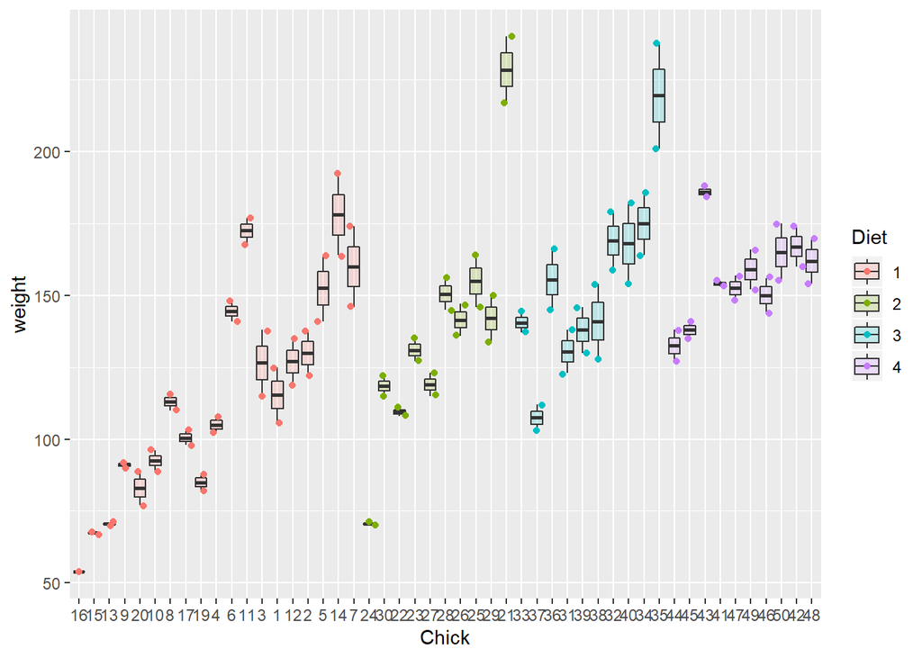

```r
library(ggplot2)

data(ChickWeight)
ggplot(subset(ChickWeight, Time > 10 & Time < 15),
    aes(x=Chick, y=weight, fill=Diet)) +
    geom_boxplot(alpha=0.2) +
    geom_jitter(aes(colour=Diet))
```

Maybe we think the boxes are too small, and we just want to compare Diets 1 and 4. And, we also decide to extend the time period to begin at t = 5. The first plot shows Diet 1 and a reasonably disperse distribution, maybe ranging from 50 to 120 on average.

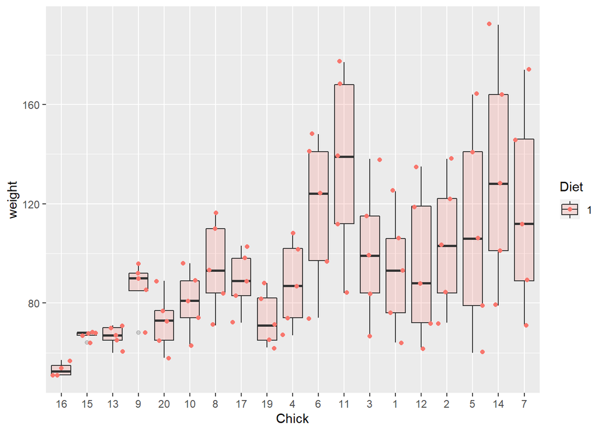

```r
ggplot(subset(ChickWeight, Time >= 5 & Time < 15 & Diet == 1),
    aes(x=Chick, y=weight, fill=Diet)) +
    geom_boxplot(alpha=0.2) +
    geom_jitter(aes(colour=Diet))
```

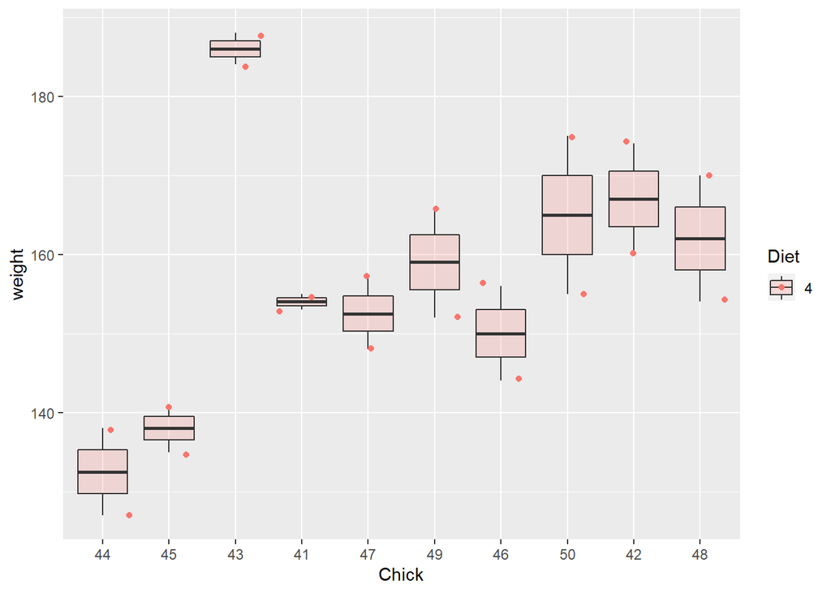

```r
ggplot(subset(ChickWeight, Time > 10 & Time < 15 & Diet == 4),
    aes(x=Chick, y=weight, fill=Diet)) +
    geom_boxplot(alpha=0.2) +
    geom_jitter(aes(colour=Diet))
```

But in the second plot weights are around 160 for Diet 4, which appears much more effective! However… there’s a typo. I forgot to change the code on the second copy and paste.

And while this is obviously a contrived example, I’m pretty sure a lot of us have made this exact mistake more than once…

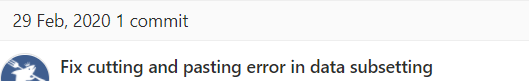

An old Git commit

Each time you have to copy and paste is just another opportunity for you to make a typo. Or, each time I want to edit something in that code, I need to make changes in as many number of places as I’ve copied it.

### Functions

There’s a little bit of a startup cost with writing a function, but if it’s code we use often, it can be worth it, and it’s also a good way to formalize how we think about what we want to accomplish. We can think about what variables we want to investigate - the lower time bound, the upper time bound, and the choice of diet. Then we use them as inputs (arguments) for the function. The variables inside the `(...)` are the arguments, and the code that is executed is inside the `{...}`.

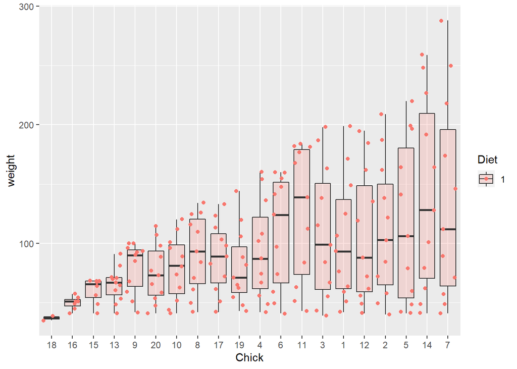

```r
plot_chickweights <- function(mintime = 0, maxtime = 21, dietc) {

plotout <- ggplot(subset(ChickWeight, Time >= mintime & Time < maxtime &
    Diet == dietc),
    aes(x=Chick, y=weight, fill=Diet)) +
    geom_boxplot(alpha=0.2) +
    geom_jitter(aes(colour=Diet))

return(plotout)

}

firstplot <- plot_chickweights(dietc = 1)
firstplot
```

Here, the function is an object in its own right, declared like any other variable. A few useful notes here: you can set default values for variables in the function call (e.g. “mintime = 0”). Then, if the variable is not declared the function still proceeds with the default value. Conversely, if you declare your own value it overwrites the default. Because of that, it is useful to explictly declare the arguments in your function call for readability. Whatever output we want we place inside “return”. If you have multiple outputs, you can place them inside a list (`return(list(a,b))`).

And, as an example imagine if you wanted to explore a large number of permutations. Eventually, readability would begin to suffer:

```r
ggplot(subset(ChickWeight, Time >= 5 & Time < 15 & Diet == 1),
    aes(x=Chick, y=weight, fill=Diet)) +
    geom_boxplot(alpha=0.2) +
    geom_jitter(aes(colour=Diet))

ggplot(subset(ChickWeight, Time >= 5 & Time < 15 & Diet == 2),
    aes(x=Chick, y=weight, fill=Diet)) +
    geom_boxplot(alpha=0.2) +
    geom_jitter(aes(colour=Diet))

ggplot(subset(ChickWeight, Time >= 5 & Time < 15 & Diet == 3),
    aes(x=Chick, y=weight, fill=Diet)) +
    geom_boxplot(alpha=0.2) +
    geom_jitter(aes(colour=Diet))

ggplot(subset(ChickWeight, Time >= 5 & Time < 15 & Diet == 4),
    aes(x=Chick, y=weight, fill=Diet)) +
    geom_boxplot(alpha=0.2) +
    geom_jitter(aes(colour=Diet))

ggplot(subset(ChickWeight, Time > 10 & Time < 15 & Diet == 1),
    aes(x=Chick, y=weight, fill=Diet)) +
    geom_boxplot(alpha=0.2) +
    geom_jitter(aes(colour=Diet))

ggplot(subset(ChickWeight, Time > 10 & Time < 15 & Diet == 2),
    aes(x=Chick, y=weight, fill=Diet)) +
    geom_boxplot(alpha=0.2) +
    geom_jitter(aes(colour=Diet))

#etc. ...
```

If we wanted to look at a large number of different plots, we can save each plot in a list (where the methods below are equivalent):

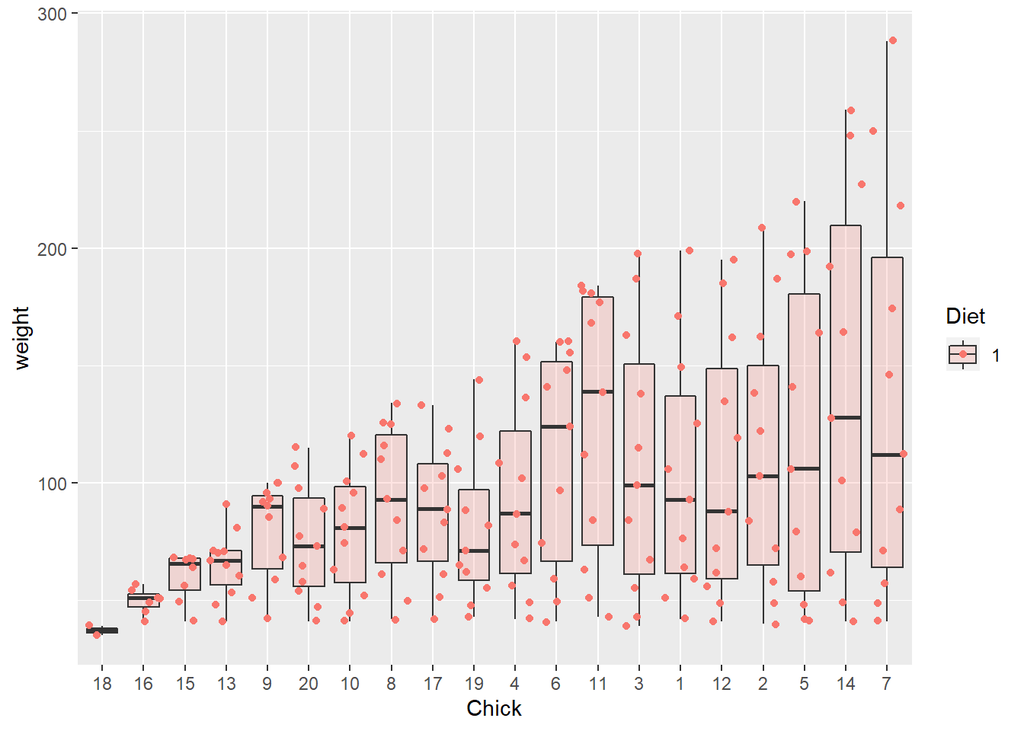

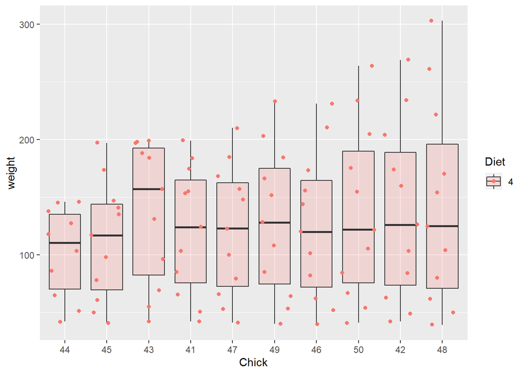

```r
plotlist <- lapply(c(1,4), plot_chickweights, mintime=0, maxtime=21)

#OR

plotlist <- lapply(c(1,4), function(x) plot_chickweights(dietc = x))

#OR

for (i in 1:2){
dieti <- c(1,4)[i]
plotlist[[i]] <- plot_chickweights(dietc = dieti)
}

plotlist
```

### Lexical scoping and three dots

Lexcial scoping refers to how R looks up the value of a variable. One specific consequence is that if a name isn’t defined inside a function, R looks one level up.

Hadley Wickham has a neat example we can steal here:

```r
x <- 2
g <- function() {
  y <- 1
  c(x, y)
}
g()
```

```
[1] 2 1
```

Even though the function does not call any arguments, and x is not definied inside the function, R loooks one level up to find x. As long as all the variables exist (and are properly named!) in the environment where the function is called, R will find them if they are missing.

However, in general, I would recommend explicitly calling your arguments for the sake of clarity. For example, if we’ve misnamed a variable or forgotten about it, the function will not be able to find the correct input and will throw an error!

Finally, we look at an example using the R ellipsis (three dots) construct. This allows you to pass additional arguments that may not be needed by your current function that could be used by some later function inside.

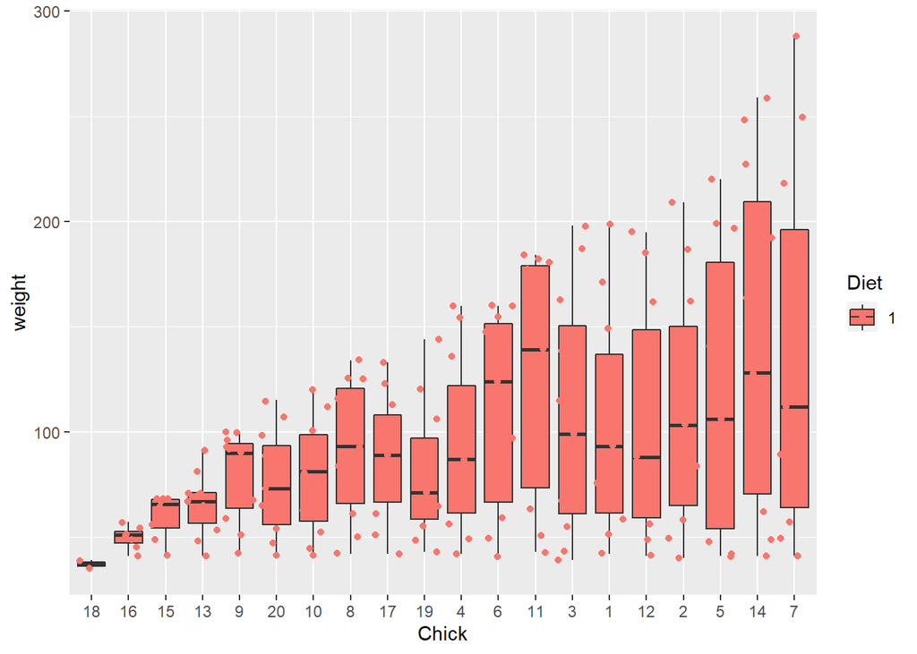

```r
plot_chickweights <- function(mintime = 0, maxtime = 21, dietc, ...) {

plotout <- ggplot(subset(ChickWeight, Time >= mintime & Time < maxtime &
    Diet == dietc),
    aes(x=Chick, y=weight, fill=Diet)) +
    geom_boxplot(...) +
    geom_jitter(aes(colour=Diet))

return(plotout)

}

plot_chickweights(dietc = 1)
```

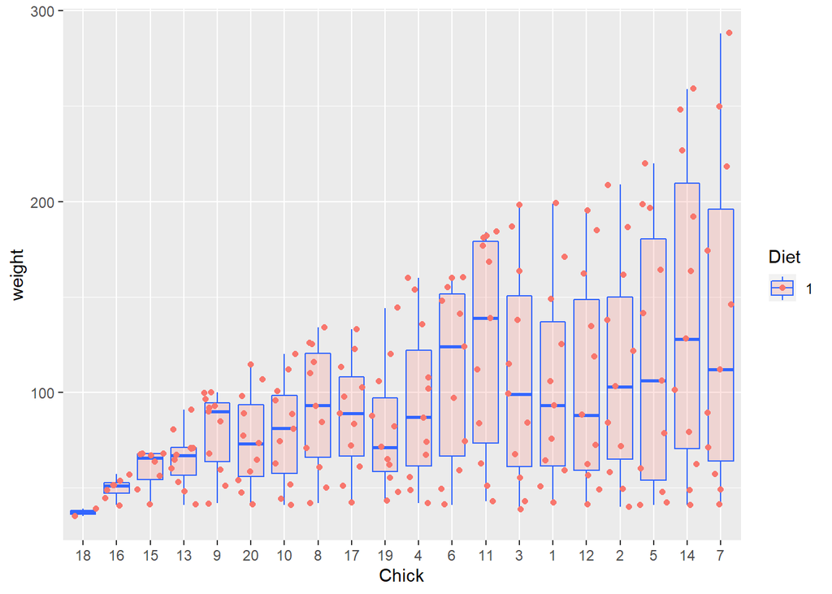

```r
plot_chickweights(dietc = 1, alpha = 0.2, colour = "#3366FF")
```

## Using functions and packages

We can use functions to clean up longer scripts. We’ll use a recreational bioeconomic model as an example of how we can organize our code. This example is an offshoot of a model developed by Scott Steinbeck and Min-Yang Lee, developed in the NW by Leif Anderson, Josh Nowlis, and Megan Stachura. Imagine a model [here](https://github.com/allen-chen-noaa-gov/nwblastarca/blob/master/inst/extdata/old_script.r) that has a number of blocks, where we might need to:

1. Load necessary data.
2. Keep track of fishery characteristics such as numbers at age, draw a stochastic recruitment.
3. Allow fishers to choose whether to take a trip, where to take a trip, and draw catches stochastically.
4. Then, account for removed catches and natural mortality, and simulate to the next year, and repeat …

First off we should note this is well done! If we think back to the lesson on best practices, etc., we have a script here that is well annotated, code that needs to be repeated gets written into a function. For example, to model recreational fishers we might need to simulate potential catches and utility from a hypothetical trip, and we may need to do this to first simulate who takes a trip, then draw catches for every choice occasion, for every month, year, etc. We certainly wouldn’t want to repeat this code or have to edit N number of different places each time we change something, and here we use the same code almost 200 lines apart - as we work on one section, we can forget to change the same code above or below, (not to mention it’s a pain!).

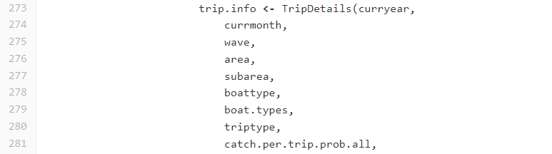

…

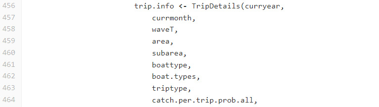

Almost 200 lines apart

But it’s still a lot to parse through. What are all those variables that are used as inputs? Where did they come from? This function depends on the time period (month, year), the area on the West Coast, the catch probabilities for each species… It’s 500-600 lines long, and you might try running it and discover you don’t have the functions, or that it tries to load data, 100 lines in.

What if, we could include all the data and functions with the code and model we wnat to share? What if, we could also include documentation that explained what variables, data, and functions are included, and start users off with a minimally reproducible example that they could follow along?

```r
library(devtools)

install_github("allen-chen-noaa-gov/nwblastarca", build_vignettes = TRUE)

library(nwblastarca)
help(package="nwblastarca")
```

[figure not shown]

Now there’s a help file

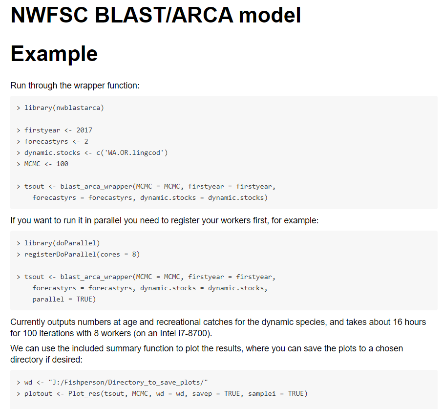

And after you click on it…

Here, we might create a high-level wrapper function that first loads data and sets up parameters that do not change across model runs (e.g. nothing stochastic) [here](https://github.com/allen-chen-noaa-gov/nwblastarca/tree/master/R/blast_arca_wrapper.r).

```r
firstyear <- 2017
forecastyrs <- 2
dynamic.stocks <- c('WA.OR.lingcod')
MCMC <- 1

filename <- system.file("extdata/lingcod", package = "nwblastarca")
WA.OR.lingcod.dynstock <- Read_SS(filename)

data(StocksRecCatchByArea)
data(NWdata)

NWdata$Modelinfo$past.trips.by.yearwaveareaboattype$Trips <-
    round((NWdata$Modelinfo$past.trips.by.yearwaveareaboattype$Trips)/100)

print(Sys.time())
blastout <- blast_arca_wrapper(MCMC = MCMC, firstyear = firstyear,
    forecastyrs = forecastyrs, stocks.rec.catch.by.area = StocksRecCatchByArea,
    datain = NWdata, dynamic.stocks = dynamic.stocks,
    dynstock = list(WA.OR.lingcod.dynstock = WA.OR.lingcod.dynstock))
print(Sys.time())

plotout <- Plot_res(blastout, MCMC, save = FALSE, samplei = TRUE)

plotout[[1]]
dev.new()
plotout[[2]]
help(package="nwblastarca")
```

All this allows us to:

- Include a reproducible example for someone who has just started looking at our project
- Include any data we need [for example](https://raw.githubusercontent.com/allen-chen-noaa-gov/nwblastarca/master/inst/extdata/lingcod/Report.sso).
- Include any packages that might be needed, and are automatically installed [for example](https://github.com/allen-chen-noaa-gov/nwblastarca/tree/master/R/Read_SS.r).

Finally, inside that wrapper we call on a function that runs the model once [here](https://github.com/allen-chen-noaa-gov/nwblastarca/tree/master/R/Bio_loop.r). If we want to simulate the model multiple times, for example to get a sense of outcomes due to stochastic catch, recruitment deviations, etc., we can just call the Bio_loop function however many times as needed.

### Parallel computing

One major benefit I have found for organizing my code this way, especially for actions that need to be repeated many times, is the ability to parallelize it. Any process that is independent of itself can be parallelized. For example, here we might want to run the model as a Monte Carlo experiment, and iterate one hundred different iterations of the recruitment deviations and realized catches, which are stochastic, to get a sense of the distribution of potential outcomes.

Because each iteration is independent (doesn’t depend on the results of another) iteration, we can parallelize this process. An example of a process that could *not* be parallelized would be calculating each year of our model - in order to calculate year 2, we have to first simulate year 1, etc. - year 2 is not independent of year 1.

While writing better and more efficient code will certainly cut down on computation time (e.g. `for` loops are notoriously slow in R compared to vectorized operations), often times a lazy and brute force solution can be to run operations in parallel, which almost all machines can do.

The package `doParallel` allows you to set up your workers, and one way you can check how many workers you can use is to look at your task manager. It’s probably a good idea to leave one core for everyday tasks if you’re using the machine for other tasks concurrently, but you can experiment to see how much processing power you end up using.

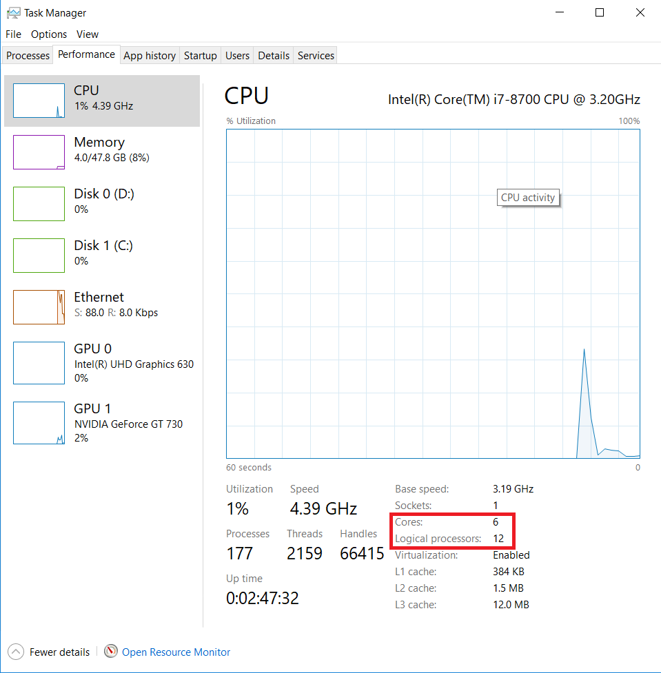

Task manager

The package `foreach` allows you to run the function in parallel. Here `Bio_loop` is a function that runs through a single iteration of our bioeconomic model. We may want to look at the distribution of recruitment deviations and realized catches, and how that affects results, which requires running multiple iterations. Here, it’ll run 100 iterations in parallel (for clarity in the example we’ve hard-coded the number of iterations). Any packages that the function needs should be passed to each worker as well.

```r
library(doParallel)
registerDoParallel(cores = 8)

library(foreach)
foreach(nn = 1:100, .packages = c("nwblastarca")) %dopar% Bio_loop(...)
```

In this example, each model run takes about 1.25 hours, and 100 iterations takes more than 5 days. Running it in parallel with 8 workers let’s us run it overnight!

## Creating a package

Now that we have a number of different functions, instead of sourcing them all at the beginning of a script, this construction lends itself naturally to package development.

There are (at least) two pieces we need before we begin. The first piece we can install straight in R.

```r
install.packages("devtools")
```

The second is Rtools which we’ll need to get [here](https://cran.r-project.org/bin/windows/Rtools/).

We can create a package structure to start with by running:

```r
library(devtools)

devtools::create("path/to/package/pkgname")
```

This will create a barebones folder structure with three pieces: a folder “R” for code, as well as a Description and Namespace file. A package may include other aspects as well (for example see below), but at its core these three pieces are all you need.

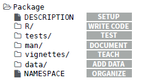

From Hadley Wickham

Simply dragging our existing functions into the `R` folder means any time we load our package (e.g. `library(nwblastarca)`) our functions are imported. The other two things to make sure to include are to tell the function to be exported by adding `#' @export`, and then using `roxygen2` to `document` it.

```r
plot_chickweights <- function(mintime = 0, maxtime = 21, dietc, ...) {
    #' @export

plotout <- ggplot(subset(ChickWeight, Time >= mintime & Time < maxtime &
    Diet == dietc),
    aes(x=Chick, y=weight, fill=Diet)) +
    geom_boxplot(...) +
    geom_jitter(aes(colour=Diet))

return(plotout)

}

setwd("path/to/package/pkgname")
library(rmarkdown)
library(roxygen2)
document()

setwd("..")
install("pkgname")
```

Now you can easily share this package with collaborators, and after they install and load the package (like any other R package), the functions will exist in your current workspace (no need to source).

### Importing used packages

In addition, you can make sure any functions from `other` packages that your package uses are also automatically installed! Editing the Namespace file allows us to do that, and while you can do so manually, we typically take advantage of `roxygen2` to do so. After the code designating our function arguments we can include: `#' @import` and then the name of our package, and the name of each function from that package. If you want to import the whole package just leave the third part blank (no function names).

```r
Read_SS <- function(filename) {
    #' Read_SS
    #'
    #' Read in a Report.sso file from Stock Synthesis for use in BLAST
    #'
    #' @param filename File path where Report.sso is located
    #'
    #' @return Stockinfo Information about stock used in BLAST model
    #' @importFrom r4ss SS_output
    #' @export
    #' @examples
    #'
    {

    #Code...

    }
```

For clarity you can also update the Description file to show that your package imports from the following packages, an example here:

```r
Package: nwblastarca
Title: Northwest recreational bioeconomic model
Version: 0.0.0.9000
Authors@R:
    person("Josh", "Nowlis", role = c("aut"))
    person("Megan", "Stachura", role = c("aut"))
    person("Leif", "Anderson", role = c("aut"))
    person("Allen", "Chen", email = "allen.chen@noaa.gov",
    role = c("aut", "cre"))
Description: Northwest recreational bioeconomic model
Imports:
    reshape2,
    data.table,
    dplyr,
    magrittr,
    pscl,
    ggplot2,
    RColorBrewer,
    r4ss,
    foreach
Suggests:
    doParallel,
    knitr,
    rmarkdown
License: Do not distribute
Encoding: UTF-8
LazyData: true
RoxygenNote: 7.1.1
VignetteBuilder: knitr
```

The default is that c(“Depends”, “Imports”, “LinkingTo”) are installed for you!

## Documenting functions and packages

There are additional benefits from compiling these functions into a package. We can document the inputs and describe them for a user who is not familiar with each function. While we can manually populate a `/man` folder in the package with `.rd` files documenting each function, simiarly to `import` above, we use `roxygen2` to automatically do this for us.

Actually documenting each function is straightforward, we use the `#'` designation again for roxygen2 to read.

```r
TripDetails <- function(
    #...
    ) {
    #' TripDetails
    #'
    #' Workhorse function used to identify choices and, subsequently, catches
    #' within a wave-area combination
    #'
    #' @param curryear Current year
    #' @param currmonth Current month
    #' @param wave Current wave
    #' @param area Larger area definitions, OR or WA
    #' ...other parameters...

    #Code for trips...

    }
```

The first line is the function name, then a short description. Eacah parameter can be listed with `@param`, then the parameter name, and then the description of the parameter. Using `roxygen2` creates the files automatically that eventually document the functions!

```r
setwd("path/to/package/pkgname")
library(rmarkdown)
library(roxygen2)
document()
setwd("..")
```

When the package is installed we can get information on the function like any other, with `?TripDetails`!

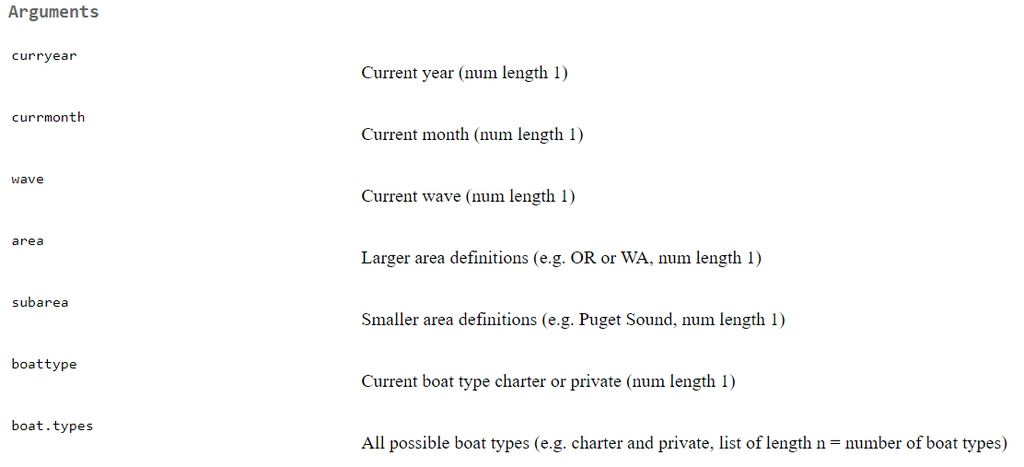

This opens as an html

`?FunctionName` takes us to the help page of that function, where we can describe what each argument does, and the input it should be (for example, a list, a numeric, etc.).

### Read me and/or vignette

Finally, some may find it beneficial to include a vignette with their package. This allows users who are not familiar with the model or code to walk through a few examples and learn about what the package can do. This requires using rmarkdown to create a markdown file (similar to your previous lesson!), that gets installed along with the package. Then, the vignette is found in the same location as the function and package documentation.

We can just create an additional folder in our package structure `vignettes`. Then, save our markdown file `.Rmd` in that folder, and add the following lines to our Description file:

```r
Suggests: knitr, rmarkdown
VignetteBuilder: knitr
```

And something like this at the header of our markdown file:

```r
---
title: "Put the title of your vignette here"
output: rmarkdown::html_vignette
vignette: >
  %\VignetteIndexEntry{Put the title of your vignette here}
  %\VignetteEngine{knitr::rmarkdown}
  \usepackage[utf8]{inputenc}
---
```

It will compile with the rest of the package then.

```r
install("nwblastarca", build_vignettes = TRUE)
help(package="nwblastarca")
```

[figure not shown]

Now there’s a help file

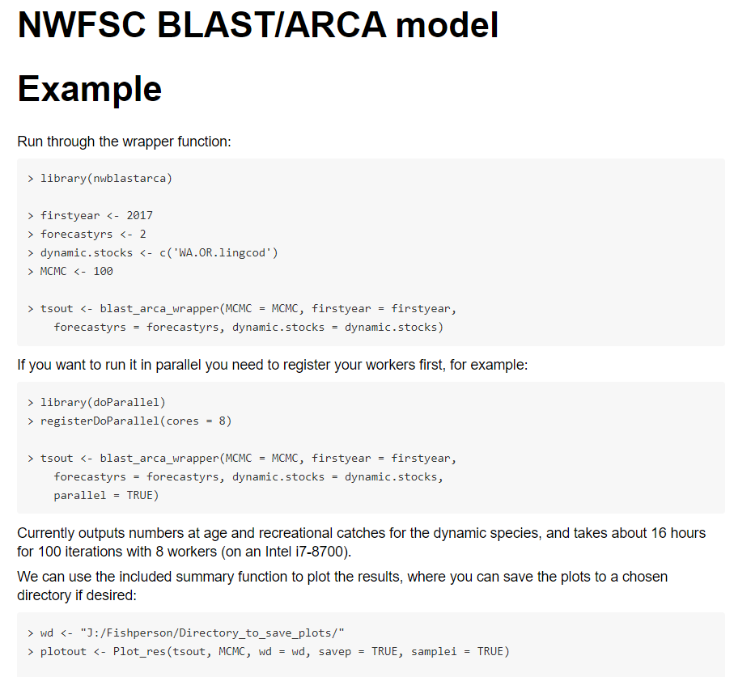

And after you click on it…

#### Read me

If you plan on sharing your package on Git, you can also include a readme. It can also function to serve a similar purpose as a walkthrough to show a minimally reproducible example.

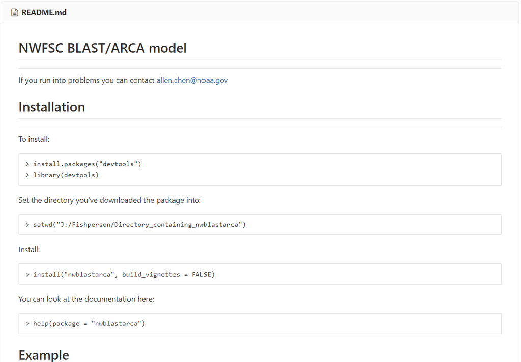

This opens as an html

### Bonus Git!

Finally, seeing as we’ve got a set of new folders, we can throw this on the internet! If you’ve already got an account (wherever you prefer), and Git is installed on your computer, you can create a new repo online, open a git bash on our new package, and:

```r
git init
git add .
git commit -m "First commit [your message here]"

git remote add origin [your link to your Github repo here]
git branch -M master
git push -u origin master
```